# Multi-Item Models in a Worksheet and in Code

Manuel D. Rossetti, PhD P.E.

## Agenda

- `Chapter4Models.xlsx`: one sheet per model, and what each layout says about the model
- The constrained sheet: named ranges, a status cell, and a button you may trust
- The exchange curve, joint replenishment, and the distribution scan
- Why there is no serial worksheet
- The software: measures and constraints, interval rules, supply networks
- The chapter’s examples, run

## Three Questions Every Sheet Answers

Every model in this chapter breaks the single-item layout: the decision is a vector, the items are tied by something that belongs to none of them, and two of the models are algorithms, not formulas. Each sheet answers three questions.

**Is this a property of an item, or of the problem?** The multiplier is one cell; a unit’s volume is a column. A multiplier repeated down a column computes the same numbers while asserting that each item has its own shadow price.

**Is this difference data, or a different sheet?** A budget and a space limit differ in one column of coefficients, so the constraint is implemented once.

**When may a button be trusted?** Goal Seek is safe on the constrained sheet because the resource function has exactly one root. Solver is not safe on the joint sheet, because the objective kinks wherever a multiplier steps, so that sheet plots the curve.

## The Constrained Sheet

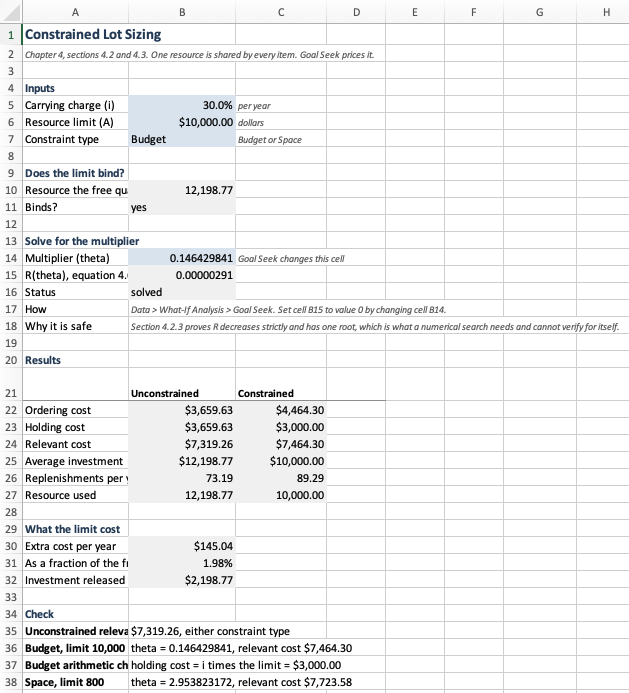

Read from the top down and it follows the chapter: inputs, **does the limit bind**, the multiplier with a status cell, the results unconstrained beside constrained, the price of the limit, and the check block.

The verdict sits **above** the multiplier, because an unconstrained solution inside the limit is the answer and nothing further needs solving.

| Cell | Formula | Which result |
| --- | --- | --- |
| `B10` | `=SUMPRODUCT(Con_a,Con_Qfree)` | resource at $Q_j^{*}$ |
| `B11` | `=IF(B10>B6,"yes","no")` | does it bind |
| `B15` | `=IF(B11="no",0,SUMPRODUCT(Con_a,Con_Qheld)-B6)` | $R(\theta)$ |
| `C23` | `=SUMPRODUCT(Con_h,Con_Qheld)/2` | holding cost |
| `C25` | `=SUMPRODUCT(Con_c,Con_Qheld)/2` | the investment |

## Named Ranges, and No Division

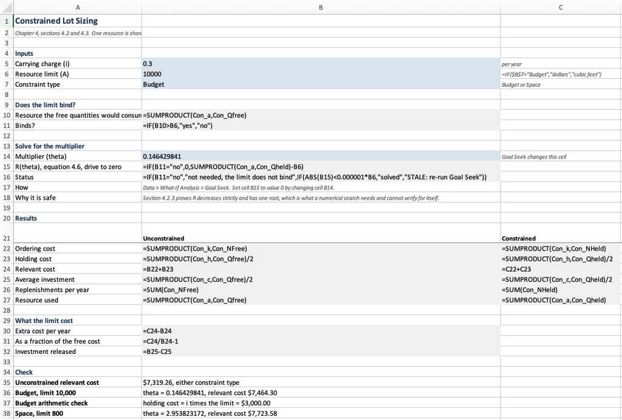

Every summary is a `SUM` of one column or a `SUMPRODUCT` of several. It **never divides one range by another**, which would evaluate zero over zero on every empty row of a hundred-row range. Where a ratio per item is needed, replenishments a year, the ratio gets its own column and the summary sums it.

## The Item Block, and the Button

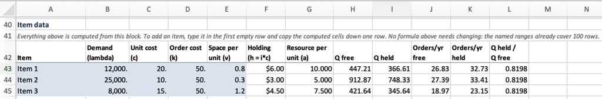

Column I is $Q_j(\theta) = \sqrt{2k_j\lambda_j/(h_j + 2\theta a_j)}$: `=SQRT(2*D43*B43/(F43+2*$B$14*G43))`. Notice that only `$B$14`, the multiplier, carries dollar signs. **Dollar signs are the spreadsheet’s only way to say what belongs to an item and what belongs to the problem.** Column G, `=IF($B$7="Budget",C43/2,E43)`, is the only thing distinguishing a budget from a space limit. The item block goes last, so adding an item is typing in the first empty row.

Goal Seek drives $R(\theta)$ to zero, and it is dependable here only because $R$ is strictly decreasing with one root. It also does not re-run by itself: change a demand rate and every result below a stale multiplier is confidently wrong. Watch the status cell, not the numbers.

## The Exchange Curve Sheet

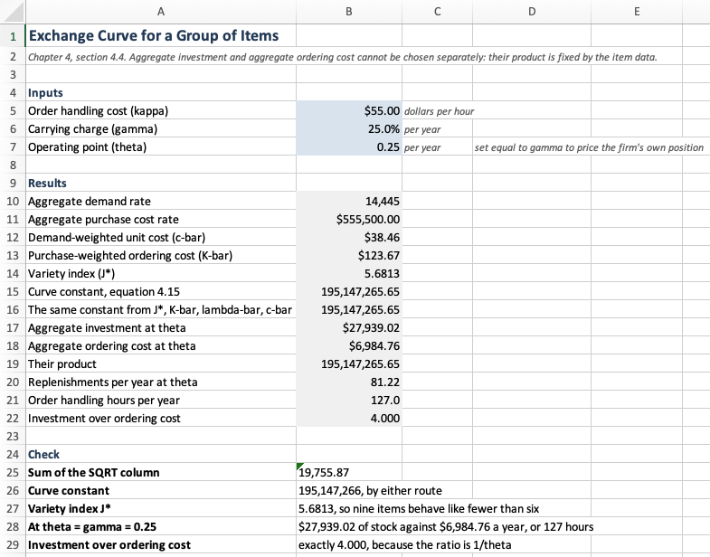

Here the multiplier is the thing **varied**, so it runs down a column and every other quantity becomes a column beside it. Is it one fact about the problem, or the axis?

Notice that the curve constant appears twice, computed two ways:

| Cell | Formula |
| --- | --- |
| `B15` | `=SUMPRODUCT(Exc_root)^2/2` |
| `B16` | `=B14*B13*B10*B12/2` |

The first squares the sum of the item column; the second multiplies the variety index by the three averages. They agree to the cent, and that agreement is the check for this sheet.

## Tracing the Curve

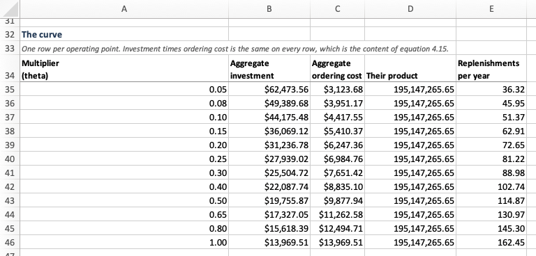

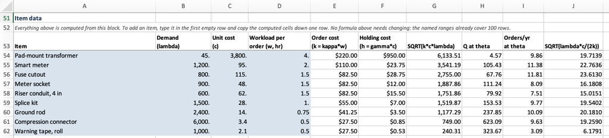

The curve is not a search: each row evaluates a closed form, and column D is the same product twelve times. Nine items sit in the item block against three on the constrained sheet, and nothing above it changed.

## Joint Replenishment: One Continuous Decision

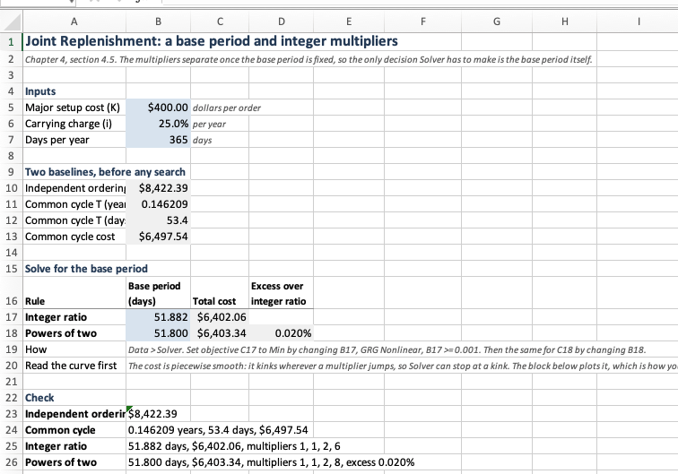

Once $T$ is fixed the multipliers separate, so the whole problem is one-dimensional: Solver has one cell to change under each rule. The two rules have **separate** base period cells, because they reach different optima, 51.882 days against 51.800.

The integer multiplier is a formula, not a search:

`=MAX(1,CEILING((-1+SQRT(1+4*(G56/($B$17/$B$7))^2))/2,1))`

The best integer for one item satisfies $m(m-1) \le (T_j^{*}/T)^2 \le m(m+1)$, and solving that pair for $m$ gives the cell. The power-of-two multiplier is the doubling test, `=2^MAX(0,CEILING(LOG(G56/(SQRT(2)*($B$18/$B$7)),2),1))`.

## The Plot Is Mandatory Here

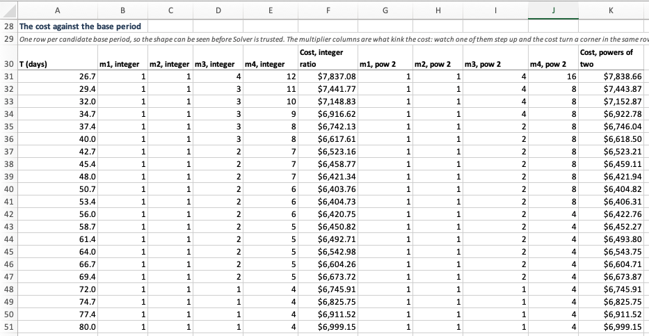

The objective is **piecewise** smooth: it kinks wherever a multiplier jumps. Watch the last multiplier step from 6 to 5 and the cost column turn a corner in the same row. A hill climber can halt at a kink, so plotting the objective is the only evidence that Solver stopped in the right basin.

On the constrained sheet the search is a button and nothing is plotted, because the chapter proves one root. Here there is no such proof. Whether you may trust an optimizer is a property of the function, established in the chapter, not on the sheet.

## The Distribution Scan

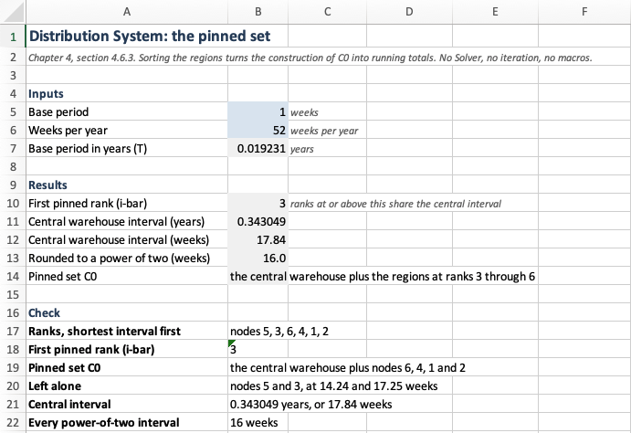

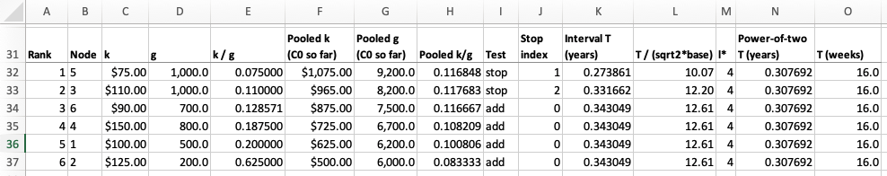

The scan reproduces the pinned-set table row for row: the candidate’s ratio beside the pooled ratio, and the verdict `=IF(E32>H32,"add","stop")`. The pooled columns are running totals, so there is no iteration, no Solver and no macro.

## Why There Is No Serial Sheet

The distribution scan has a fixed number of steps known in advance, one per region, and each depends only on the one before. That is a table.

The serial partition has none of those properties. The number of blocks is not known until the walk is finished, and a `merge` changes blocks already built. **The absence of a serial worksheet is an answer, not an omission.**

A worksheet cannot bracket its own root or widen its own search; it cannot hold a structure whose size is not known until the computation finishes; and it cannot be audited at three thousand items.

None of that makes the worksheets inferior. They are better at what they are for, making a method visible: the joint sheet shows what a one-dimensional search over a base period is, and no loop shows that. What a worksheet cannot do is what the software is for.

## What the Software Must Do

| # | The software must | From |
| --- | --- | --- |
| R1 | compute each SKU’s order quantity ignoring any coupling | the EOQ chapter |
| R2 to R5 | measure a plan; decide whether a limit binds; solve under it and report the shadow price; price the limit | the constrained problem |
| R6 | trace the frontier of achievable positions | the exchange curve |
| R7, R8 | schedule SKUs sharing one setup under a stated practice; restrict intervals to what can run | joint replenishment |
| R9, R10 | account for holding across locations; find intervals across a chain or network | multi-echelon |

The nouns that pass the warehouse test: **SKU**, **portfolio**, **aggregate measure**, **constraint**, **replenishment plan**, **order family**, **interval rule**, **supply network**. *Shared resource* fails: nobody has one. They have a capital account, a floor and a purchasing department, each a **measure** with a ceiling.

## Measuring, and Limiting a Measure

Relevant cost is measured constantly and constrained never, so the interface splits: `AggregateMeasure` is what can be measured, and `ConstrainableMeasure` adds what a limit needs. The stationarity condition is $-k_j\lambda_j/Q_j^{2} + h_j/2 + \theta\,\partial M/\partial Q_j = 0$, so a measure that reports its marginal can always be solved numerically:

```kotlin
interface ConstrainableMeasure : AggregateMeasure {
    fun marginalAt(sku: SKU, orderQuantity: Double): Double
    fun quantityAt(sku: SKU, shadowPrice: Double): Double { /* bisect the condition */ }
}

object AverageInvestment : ConstrainableMeasure {
    override fun marginalAt(sku: SKU, orderQuantity: Double): Double = sku.unitValue / 2.0
    override fun quantityAt(sku: SKU, shadowPrice: Double): Double =
        sqrt(2.0 * sku.orderCost * sku.demandRate / (sku.holdingRate + shadowPrice * sku.unitValue))
}

object ReplenishmentWorkload : ConstrainableMeasure {
    override fun marginalAt(sku: SKU, orderQuantity: Double): Double =
        -sku.demandRate / (orderQuantity * orderQuantity)
    override fun quantityAt(sku: SKU, shadowPrice: Double): Double =
        sqrt(2.0 * (sku.orderCost + shadowPrice) * sku.demandRate / sku.holdingRate)
}
```

`AverageInvestment.quantityAt` is $Q_j(\theta)$ with $a_j = c_j/2$, the only place the formula appears. A workload’s marginal is negative and depends on the quantity, which **no single coefficient $a_j$ can express**.

## One Search for Every Limit

```kotlin
class LagrangianSearch(private val precision: Double = 1.0E-12,
                       private val maximumIterations: Int = 400) : LotSizingMethod {
    override fun solve(portfolio: Portfolio, constraint: Constraint): ReplenishmentPlan {
        val measure = constraint.measure
        var lo = 0.0
        var hi = 1.0
        while (constraint.slackIn(portfolio.planAt(measure, hi)) < 0.0) {
            hi *= 2.0
            check(hi < 1.0E12) { "No price high enough to meet the ${measure.name} limit" }
        }
        repeat(maximumIterations) {
            val mid = 0.5 * (lo + hi)
            if (hi - lo < precision) return@repeat
            if (constraint.slackIn(portfolio.planAt(measure, mid)) < 0.0) lo = mid else hi = mid
        }
        return portfolio.planAt(measure, 0.5 * (lo + hi))
    }
}
```

Notice what the search does not know. It never writes $Q_j(\theta)$, never names a budget, and never asks what the measure is. It knows only that raising the price lowers consumption, which the chapter proves. The first loop widens the bracket until the slack changes sign, the step Goal Seek does not take.

## Interval Rules and Supply Networks

```kotlin
interface IntervalRule {
    val basePeriod: Double
    fun implementable(preferredInterval: Double): Double
    fun multiplierFor(preferredInterval: Double): Int =
        max(1, Math.round(implementable(preferredInterval) / basePeriod).toInt())
}

abstract class SupplyNetwork(val skus: List<SKU>, private val suppliedBy: Map<SKU, SKU>) {
    fun echelonRate(sku: SKU): Double =
        sku.holdingRate - (suppliedBy[sku]?.holdingRate ?: 0.0)
    abstract fun relaxedIntervals(): List<Double>
    fun plan(rule: IntervalRule): List<Double> = relaxedIntervals().map { rule.implementable(it) }
}
```

Coordinating a family and rounding an interval look like two jobs; they are one job with different answers, so one interface serves a SKU in a family, a block in a chain, and a location in a network. `echelonRate` gives $h_i - h_{i+1}$ down a chain, $h_i - h_0$ across a network, and a location with no supplier its own rate, from one expression.

## The Chapter’s Examples, Run

```kotlin
val study = ConstrainedLotSizing(storeroom, Constraint(AverageInvestment, limit = 10000.0))
study.binds                                  // true
val held = study.solve()
held.shadowPrice                             //     0.146430
held.measuredBy(AverageInvestment)           // 10000.0000
held.measuredBy(RelevantCost)                //  7464.2984
study.priceOfTheConstraint()                 // difference 145.0375, 1.9816%
study.quantityRatios()                       // 0.819755 three times
```

Changing the constraint changes one word, `Constraint(ReplenishmentWorkload, limit = 50.0)`:

```
  shadow price             64.3293 per order
  Item 1   k+theta 114.3293   held  676.2523   ratio 1.5121
  Item 2   k+theta  84.3293   held 1185.5328   ratio 2.0534
  Item 3   k+theta 144.3293   held  716.3594   ratio 1.3432
  orders per year          50.0000
  relevant cost          7621.2652
  the limit cost          805.9328  (11.8253%)
```

Under the budget every item shrank by 0.819755; here they grow by 1.51, 2.05 and 1.34. The code reproduces the difference between rescaling and reallocating, and no type in the program knows that the difference exists.

## Families, Chains and Networks, Run

```
  independent              8422.39
  common cycle             6497.54   T = 0.14621 year (53.4 days)
  integer multiple         6402.06   T = 0.14214 year (51.882 days)   m = [1, 1, 2, 6]
  power of two             6403.34   T = 0.14192 year (51.800 days)   m = [1, 1, 2, 8]
  nesting costs             0.0200%
  the schedule nests    true
```

```kotlin
val chain = SerialChain(stages)
chain.blocks()                               // {1,2} at 0.5933, {3,4,5} at 0.6234
chain.costOf(chain.relaxedIntervals())       // 183.25
val weekly = PowerOfTwoMultiple(1.0 / 52.0)
chain.costOf(chain.plan(weekly))             // 183.31
val network = DistributionNetwork(warehouse, regions)
network.pinnedSet()                          // 6, 4, 1, 2
network.centralInterval()                    // 0.343049
network.plan(weekly)                         // every location at 0.307692
```

The same `weekly` object goes to a chain and to a network, and neither asks what it is. The last line of the family output checks the chapter’s argument instead of accepting it: `nestsOn` asks the answer whether it nests.

## What We Did Today

**Each sheet’s layout is a statement about the model:** one cell for a fact about the problem, a column for a fact about an item or for the axis being varied.

**A button may be trusted when the chapter proves it:** Goal Seek on one root, Solver with the curve plotted beside it.

**The serial partition has no sheet,** because its number of steps is not known until it finishes.

**The software limits a measure, not a budget,** solves every limit with one search, and serves families, chains and networks with one interval rule.

**Every number in the chapter comes from running it,** and each is checked a second way.

## For Next Time

**Read before next session:** *Dynamic Lot Sizing*, through *What a Plan Costs*.

Today’s material was *Building These Models in a Worksheet* and *Designing the Software*.

Next session:

- What happens when the demand rate changes from period to period
- Why the economic order quantity has nothing to minimize, and what replaces it
- Three plans without any theory, costed by hand

Every model so far assumed a constant demand rate. Next session removes it.

⌂ Index